# H1B Data - Factor Analysis

Ashita Shetty

```r
library(psych)
library(readr)
h1b <- read.csv("C:\\Users\\Dell\\Desktop\\RBS\\Semester II\\Multivariate Analysis\\Assignment\\data\\H1_B-2014.csv", row.names = 1)
attach(h1b)
h1b[1]
```

[output not shown]

[output cut: 19942 more lines]

[output not shown]

##### **1. Decide how many Factors are ideal for your dataset**

```r
h1b$WAGE_RATE_FROM <- as.numeric(h1b$LCA_CASE_WAGE_RATE_FROM)
h1b$EMPLOYER_POSTAL_CODE <- as.numeric(h1b$LCA_CASE_EMPLOYER_POSTAL_CODE)
h1b$EMP_DIFF <- as.numeric(h1b$EMP_DIFF)
h1b$APP_DIFF <- as.numeric(h1b$APP_DIFF)
h1b$TOTAL_WORKERS <- as.numeric(h1b$TOTAL_WORKERS)
h1b$YR_SOURCE <- as.numeric(h1b$YR_SOURCE_PUB_1)
h1b$NAICS_CODE <- as.numeric(h1b$LCA_CASE_NAICS_CODE)
```

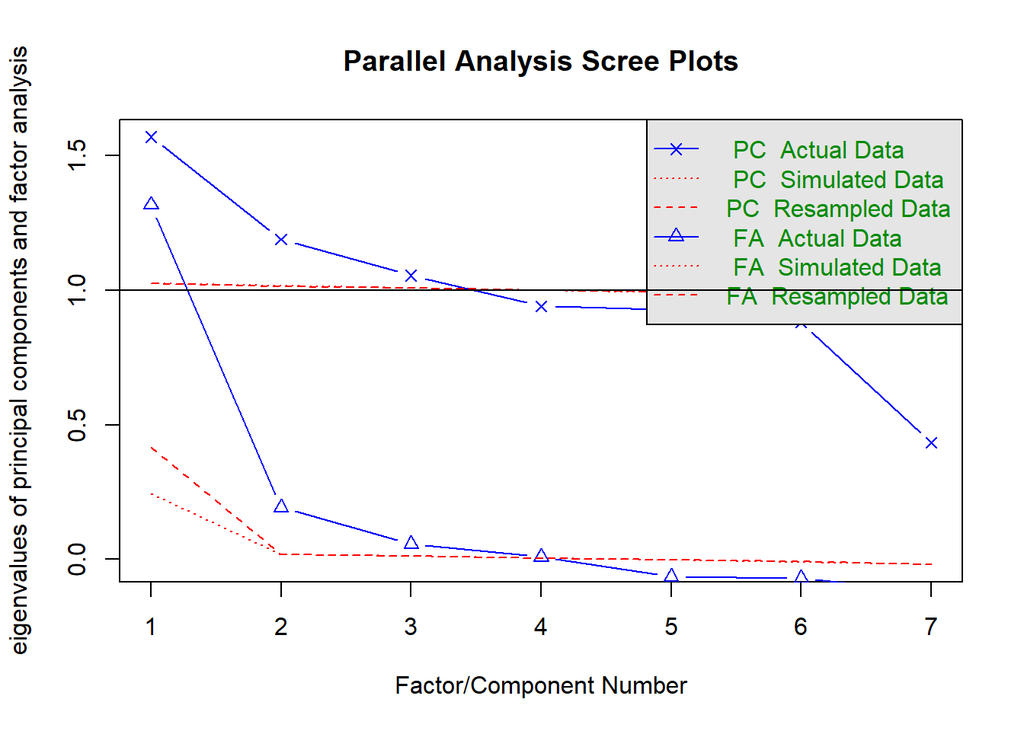

```
## Parallel analysis suggests that the number of factors =  3  and the number of components =  3
```

```r
fa.parallel(h1b[, c("WAGE_RATE_FROM", "EMPLOYER_POSTAL_CODE", "APP_DIFF", "EMP_DIFF", "TOTAL_WORKERS", "YR_SOURCE", "NAICS_CODE")])
```

**Inference:**

##### **2. Explain the output for your factor model**

```r
fit.pc <- principal(h1b[, c("WAGE_RATE_FROM", "EMPLOYER_POSTAL_CODE", "APP_DIFF", "EMP_DIFF", "TOTAL_WORKERS", "YR_SOURCE", "NAICS_CODE")], nfactors=2, rotate="varimax")
fit.pc
```

```
## Principal Components Analysis
## Call: principal(r = h1b[, c("WAGE_RATE_FROM", "EMPLOYER_POSTAL_CODE",
##     "APP_DIFF", "EMP_DIFF", "TOTAL_WORKERS", "YR_SOURCE", "NAICS_CODE")],
##     nfactors = 2, rotate = "varimax")
## Standardized loadings (pattern matrix) based upon correlation matrix
##                        RC1   RC2     h2   u2 com
## WAGE_RATE_FROM        0.00  0.54 0.2876 0.71 1.0
## EMPLOYER_POSTAL_CODE  0.12  0.64 0.4221 0.58 1.1
## APP_DIFF              0.88 -0.04 0.7808 0.22 1.0
## EMP_DIFF              0.03  0.39 0.1553 0.84 1.0
## TOTAL_WORKERS        -0.05 -0.03 0.0038 1.00 1.7
## YR_SOURCE            -0.88  0.04 0.7760 0.22 1.0
## NAICS_CODE            0.01 -0.58 0.3348 0.67 1.0
##
##                        RC1  RC2
## SS loadings           1.57 1.19
## Proportion Var        0.22 0.17
## Cumulative Var        0.22 0.39
## Proportion Explained  0.57 0.43
## Cumulative Proportion 0.57 1.00
##
## Mean item complexity =  1.1
## Test of the hypothesis that 2 components are sufficient.
##
## The root mean square of the residuals (RMSR) is  0.13
##  with the empirical chi square  14745.37  with prob <  0
##
## Fit based upon off diagonal values = -0.04
```

**Inference:**

```r
round(fit.pc$values, 3)
```

```
## [1] 1.571 1.190 1.055 0.941 0.929 0.881 0.434
```

```r
fit.pc$loadings
```

```
##
## Loadings:
##                      RC1    RC2
## WAGE_RATE_FROM               0.536
## EMPLOYER_POSTAL_CODE  0.115  0.639
## APP_DIFF              0.883
## EMP_DIFF                     0.393
## TOTAL_WORKERS
## YR_SOURCE            -0.880
## NAICS_CODE                  -0.579
##
##                  RC1   RC2
## SS loadings    1.571 1.190
## Proportion Var 0.224 0.170
## Cumulative Var 0.224 0.394
```

**Inference:**

- The loadings give the correlation, and leave out the values that may be way below a threshold making it unimportant.
- An inference of how heavily correlated APP_DIFF(positive correlation) and YR_SOURCE(negative correlation) are to RC1 can be drawn.

```r
fit.pc$communality
```

```
##       WAGE_RATE_FROM EMPLOYER_POSTAL_CODE             APP_DIFF
##          0.287562955          0.422110860          0.780803990
##             EMP_DIFF        TOTAL_WORKERS            YR_SOURCE
##          0.155293967          0.003787643          0.776035913
##           NAICS_CODE
##          0.334783626
```

**Inference:**

- Lowest communality strengthens the deciding factor of whether or not a specific column can be kept due to their low score.
- For instance, in the case of H1B data, it can be observed that TOTAL_WORKERS has the least communality score, followed by EMP_DIFF, and more.

```r
fit.pc$scores
```

[output not shown]

[output cut: 19942 more lines]

[output not shown]

**Inference:**

- The scores represent the transformed data in the factor analysis.

##### **3. Show the columns that go into each factor**

- Visualizing the relationship can help understand which columns go into the respective factors

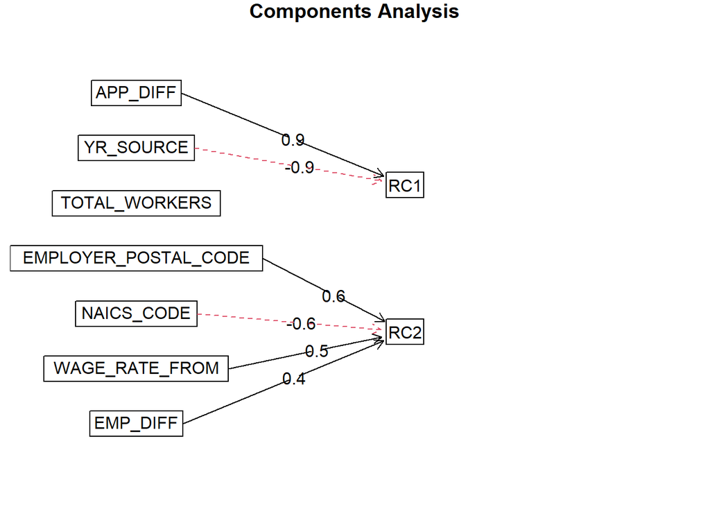

```r
fa.diagram(fit.pc)
```

**Inference:**

##### **4. Perform some visualizations using the factors**

**Correlations within Factors**

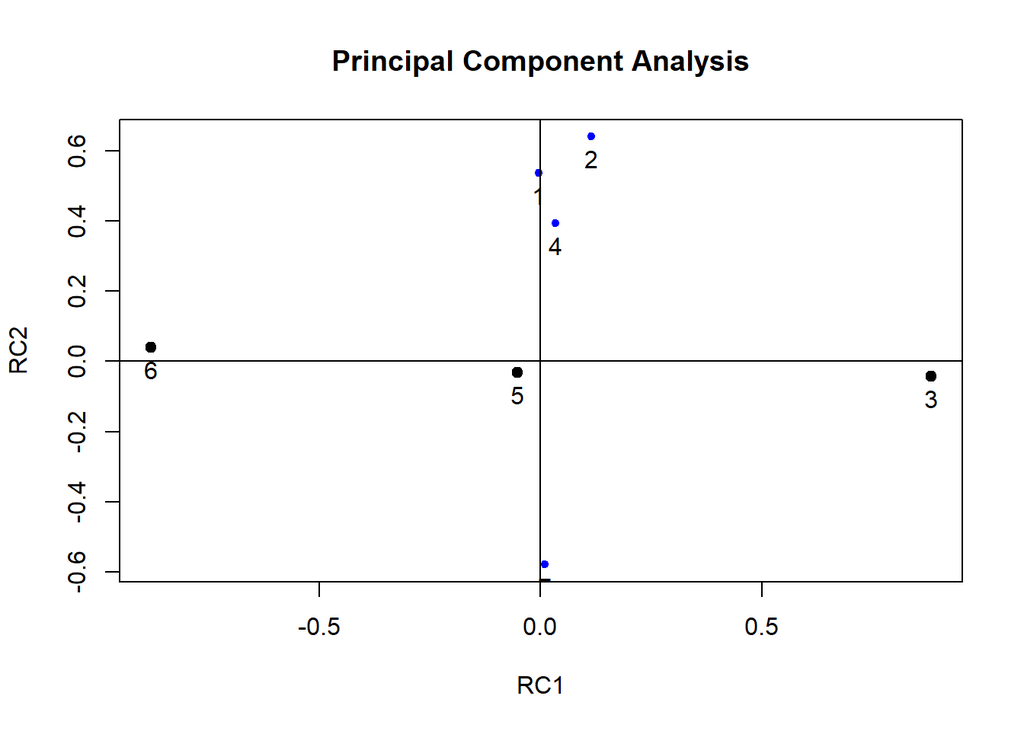

```r
fa.plot(fit.pc)
```

**Inference:**

- This diagram can help interpret the relationship between the factors.
- This is a two dimensional representation due to 2 factors chosen.

**Factor Recommendations for a Simple Structure**

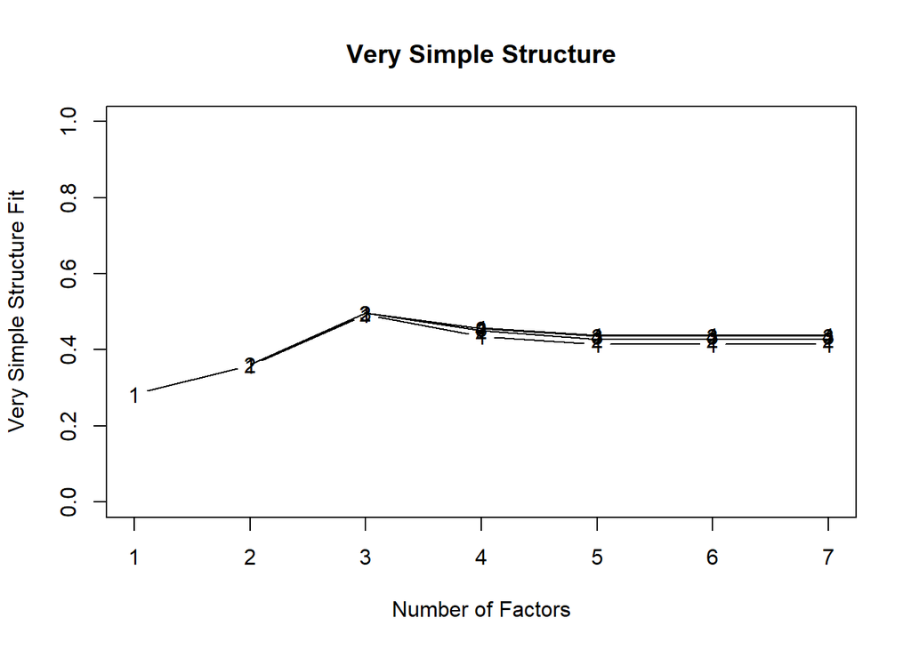

```
##
## Very Simple Structure
## Call: vss(x = h1b[, c("WAGE_RATE_FROM", "EMPLOYER_POSTAL_CODE", "APP_DIFF",
##     "EMP_DIFF", "TOTAL_WORKERS", "YR_SOURCE", "NAICS_CODE")])
## VSS complexity 1 achieves a maximimum of 0.49  with  3  factors
## VSS complexity 2 achieves a maximimum of 0.5  with  3  factors
##
## The Velicer MAP achieves a minimum of 0.05  with  1  factors
## BIC achieves a minimum of  -8.34  with  3  factors
## Sample Size adjusted BIC achieves a minimum of  1.2  with  3  factors
##
## Statistics by number of factors
##   vss1 vss2   map dof   chisq     prob sqresid  fit RMSEA   BIC SABIC complex
## 1 0.28 0.00 0.047  14 6.4e+02 1.2e-127     5.5 0.28 0.047 502.0 546.5     1.0
## 2 0.36 0.36 0.080   8 1.4e+02  1.9e-26     4.9 0.36 0.029  61.2  86.7     1.2
## 3 0.49 0.50 0.133   3 2.1e+01  8.8e-05     3.9 0.50 0.018  -8.3   1.2     1.1
## 4 0.44 0.45 0.245  -1 7.7e-06       NA     4.2 0.46    NA    NA    NA     1.3
## 5 0.41 0.43 0.523  -4 1.8e-11       NA     4.3 0.44    NA    NA    NA     1.2
## 6 0.41 0.43 1.000  -6 0.0e+00       NA     4.3 0.44    NA    NA    NA     1.3
## 7 0.41 0.43    NA  -7 0.0e+00       NA     4.3 0.44    NA    NA    NA     1.3
##    eChisq    SRMR eCRMS   eBIC
## 1 1.3e+03 3.9e-02 0.048 1141.4
## 2 2.3e+02 1.6e-02 0.027  147.0
## 3 2.3e+01 5.2e-03 0.014   -7.2
## 4 9.2e-06 3.3e-06    NA     NA
## 5 5.5e-12 2.6e-09    NA     NA
## 6 8.3e-12 3.1e-09    NA     NA
## 7 8.3e-12 3.1e-09    NA     NA
```

```r
vss(h1b[, c("WAGE_RATE_FROM", "EMPLOYER_POSTAL_CODE", "APP_DIFF", "EMP_DIFF", "TOTAL_WORKERS", "YR_SOURCE", "NAICS_CODE")])
```

**Inference:**

- According to the results provided by Very Simple Structure, the optimal no. of factors is **3 Factors** with both **VSS complexity 1 and VSS complexity 2**.
- Lower BIC values indicate better model, and the minimum **BIC value** in our case is at **3 factors**. Similarly, **Sample Size adjusted BIC** gives a minimum at **3 factors**.
- The **Velicer MAP** achieves its minimum score at **1 factor**, however, it is considered less reliable compared to the other results while determining the ideal number of factors.
- The graph result does not provide much clarity due to its overlapping nature.

##### **Based on the results above, visualizing the relationship for 3 factors**

```r
fit.pc_2 <- principal(h1b[, c("WAGE_RATE_FROM", "EMPLOYER_POSTAL_CODE", "APP_DIFF", "EMP_DIFF", "TOTAL_WORKERS", "YR_SOURCE", "NAICS_CODE")], nfactors=3, rotate="varimax")

round(fit.pc_2$values, 3)
```

```
## [1] 1.571 1.190 1.055 0.941 0.929 0.881 0.434
```

```r
fit.pc_2$loadings
```

```
##
## Loadings:
##                      RC1    RC2    RC3
## WAGE_RATE_FROM               0.570
## EMPLOYER_POSTAL_CODE         0.662
## APP_DIFF              0.884
## EMP_DIFF                     0.250  0.671
## TOTAL_WORKERS               -0.211  0.765
## YR_SOURCE            -0.882
## NAICS_CODE                  -0.561 -0.135
##
##                  RC1   RC2   RC3
## SS loadings    1.569 1.185 1.062
## Proportion Var 0.224 0.169 0.152
## Cumulative Var 0.224 0.393 0.545
```

**Inference:**

- The loadings is providing relationship between different columns and their respective relations with RCs.
- We can observe the cumulative variance for 3 factors, and it is observable how not much variance increases in RC2, and RC3.

```r
fit.pc_2$communality
```

```
##       WAGE_RATE_FROM EMPLOYER_POSTAL_CODE             APP_DIFF
##            0.3339629            0.4443303            0.7808646
##             EMP_DIFF        TOTAL_WORKERS            YR_SOURCE
##            0.5131613            0.6309790            0.7772413
##           NAICS_CODE
##            0.3348145
```

**Inference:**

- As a comparative study, it can be observed that in the case of 3 factors, TOTAL_WORKERS does not have the lowest communality.
- Instead ‘WAGE_RATE_FROM’ has the lowest communality score here.

```r
fit.pc_2$scores
```

[output not shown]

[output cut: 19942 more lines]

[output not shown]

**Inference:**

- The scores represent the transformed data in the factor analysis. In this case, for factor = 3

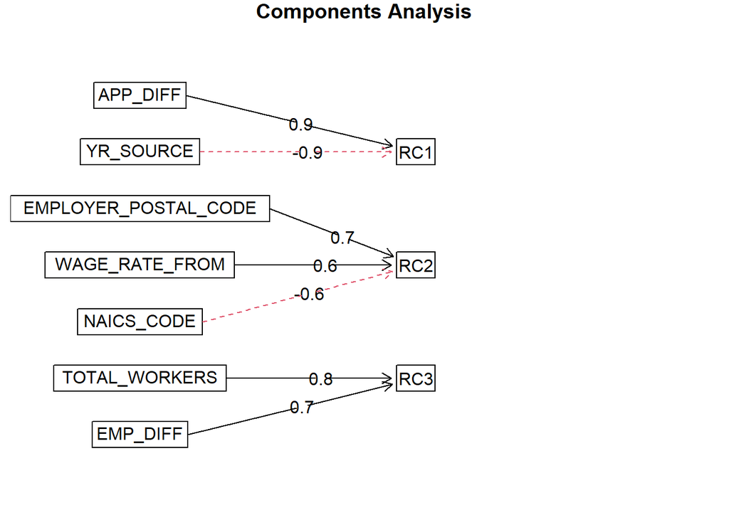

```r
fa.diagram(fit.pc_2)
```

**Inference:**